# CO2-Analysis-with-PCA-and-KPCA

Callum Weinberg

May 26, 2022

# Packages

Install the following libraries to run this project. ncdf4 is only needed if the first code chunk is to be run.

```r
# Data loading
library(ncdf4)

# Data cleaning and manipulation
library(stringr)
library(dplyr)
library(tidyr)
library(rematch)
library(lubridate)

# Plotting
library(ggplot2)
library(devtools)
#install_github("vqv/ggbiplot")
library(ggbiplot)
library(cowplot)

# Geographic Mapping
library(tmap)
library(sf)

# Modeling
library(pls)
library(kernlab)
library(car)

# Other
library(knitr)
```

# Data Processing

### Load the Vulcan CO2 Data

The below code chunk processes the raw Vulcan CO2 data. The data sets are very large (80 files, approximately 30 GB in total size). If you'd like to rerun/change this portion of the code, you will have to download the data. See Raw/Vulcan_CO2/March2014/List_of_Files.txt for a list of the files.

```r
# Indicate String Path
path = "Raw/Vulcan_CO2/March2014/"

# Get a list of files from the folder
files_list = list.files(path)

# Specify the name of the variable to be accessed
# there are multiple variable available so this is
# necessary
dname = "carbon_emissions"

# Create a dataframe to store the data from each file
combined_df = data.frame(Type = "Holder",
                        FileName = "holder",
                        CO2 = NA,
                        CO2Units = NA,
                        Time = NA,
                        TimeUnits = NA)

# Loop over all files
for(i in files_list){

  # Get Type
  type =
    str_remove(
      str_remove(
        str_extract(i,"1km\\..+\\.mn"),
        "1km\\."),
      "\\.mn")


  # Open the nc file type
  nc =  nc_open(paste0(path,i))

  # Get Spacial and Time Data
  x = ncvar_get(nc,"x")
  y = ncvar_get(nc,"y")
  time = ncvar_get(nc,"time")
  tunits = ncatt_get(nc,"time","units")

  # Get CO2 Data and Units
  CO2 = ncvar_get(nc,dname)
  dunits = ncatt_get(nc,dname,"units")

  # Limit to Chosen LA Boundaries (in Meters, Lambert_Conformal_Conic Projection)
  # Code from Climatemodel_demo_CESM1.Rmd
  ys = which(y >= -401193.688560163 & y <=  -353976.762435499)
  xs = which(x >= -1942544.51850291 & x <= -1880037.22186271)

  # Get Average over all censors in the chosen boundaries, by hour
  CO2avg = apply(CO2[xs,ys,],3,function(i) mean(i, na.rm = TRUE))

  # Create Dataframe of data to append
  forappend = data.frame(Type = rep(type,12),
                         FileName = rep(i,12),
                         CO2 = CO2avg,
                         CO2Units = rep(dunits$value,12),
                         Time = time,
                         TimeUnits = rep(tunits$value,12))

  # Add the new data to the previous data
  combined_df = rbind(combined_df,forappend)

  # Clean out reused variables
  remove(type,nc,x,y,time,tunits,CO2,dunits,ys,xs,CO2avg,forappend)
}

# Save out so this code does not need to be rerun often
# took about 30 minutes on my machine
save(combined_df,file = "Intermediate/CO2_Long_v1.Rdata")
```

Start with the below code chunk. The CO2 data is in long form. The date variable is cleaned and set to Pacific Standard time. The CO2 data is reshaped wide as well for use in the modeling portion of the reports.

```r
# Load the Output from Above. Takes 20-30 minutes to run, avoid
# rerunning if possible
load(file = "Intermediate/CO2_Long_v1.Rdata")

# Remove top Row
CO2_Long_V1 = combined_df[-c(1),]

# Cleant The Date Variable
CO2_Long_V1 = CO2_Long_V1 %>%
  mutate(Date.Time = as.POSIXct(Time*3600,origin='2010-01-01 00:00:00')) %>%
  mutate(Date.Time = Date.Time - hours(8) - minutes(30))

# Wide Format
CO2_Wide_V1 = CO2_Long_V1 %>%
  select(Type,CO2,Date.Time) %>%
  pivot_wider(names_from = Type, values_from = CO2)

save(CO2_Wide_V1,file = "Intermediate/CO2_Wide_v1_using.Rdata")
remove(combined_df)
```

### Load the EPA Ozone Data

Similar to the Vulcan data, the EPA Ozone data is large (but only about 2 GB). This chunk can be skipped. If you would like to run it, unzip the "Raw/EPA_Air_Data/hourly_44201_2014.zip" file.

```r
# Load full dataest. It is 2 GB,
# So have written this code in such a way that
# this code chunk should only be run once
ozone_full = read.csv("Raw/EPA_Air_Data/hourly_44201_2014.csv", header = TRUE)

# Limit it to Los Angeles County
ozone_la_california = ozone_full %>%
  filter(State.Name == "California", County.Name == "Los Angeles")

# Remove the large Dataset
remove(ozone_full)

# Save for future use
save(ozone_la_california,file = "Intermediate/ozone_la_california.Rdata")
```

```r
# Load Limited Dataset
load("Intermediate/ozone_la_california.Rdata")

# Limit the Data to March, 2014
# Limit to Data from the WGS 1984 Projection
ozone_la_california_limited = ozone_la_california %>%
  filter(substr(Date.Local,1,7) == "2014-03") %>%
  filter(Datum == "WGS84")
```

The below code plots the ozone monitors Additionally, a transformation of the WGS84 to Lambert Conformal Conic is extracted in order to get the bounds of the CO2 data to keep (this transformation in meters is used in the Vulcan Data code chunk). Also a shapefile for CA counties is loaded for the mapping.

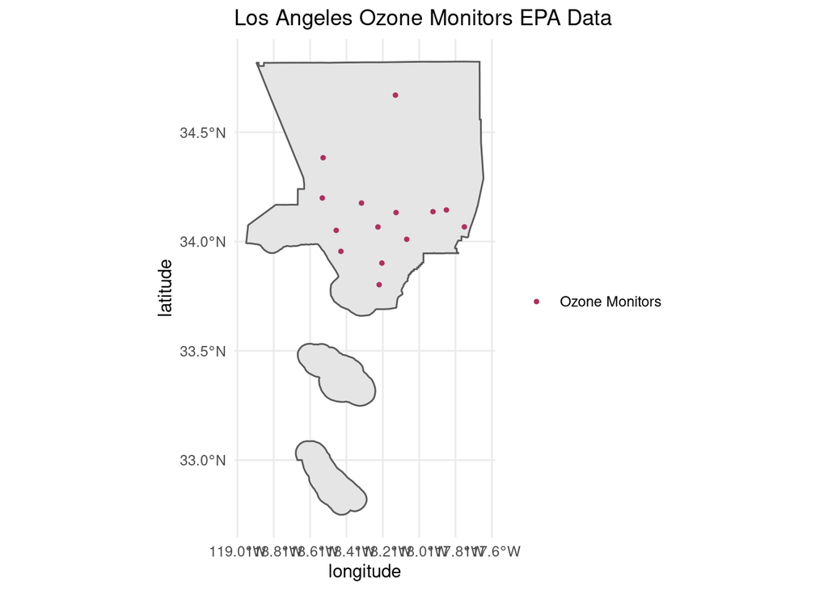

The average ozone by hour (excluding two site monitors that are in the northern portion of LA county) over the monitors is calculated save saved to the Intermediate folder for future use. The Date.Time variable is converted to be of the same form as in the CO2 data.

```r
# Get the Average Ozone by date and hour
ozone_la_california_collapsed = ozone_la_california_limited %>%
  filter(Site.Num != 9033 & Site.Num != 6012) %>%
  group_by(Date.Local,Time.Local,Units.of.Measure, Datum) %>%
  dplyr::summarise(Sample.Measurement = mean(Sample.Measurement)) %>%     # Need to specify dplyr here, otherwise package issues
  as.data.frame() %>%
  #unite(Date.Time, Date.Local, Time.Local, sep = "-", remove = TRUE) %>%
  mutate(Date.Time = paste0(Date.Local, "-", Time.Local)) %>%
  mutate(Date.Time = str_replace(Date.Time,":","-")) %>%
  mutate(Date.Time = ymd_hm(Date.Time)) %>%
  select(-Date.Local,-Time.Local)
```

```
## 'Units.of.Measure'. You can override using the `.groups` argument.
```

```r
# Save out
save(ozone_la_california_collapsed,file = "Intermediate/Ozone_CA_LA.Rdata")
remove(ozone_la_california,ozone_la_california_limited)
```

### Merge Datasets

The CO2 and Ozone data sets are merged (wide format) below.

### Save Out Data

Save out the main dataframe for graphic, Ozone_CO2_Combined (and a long version for graphic). Additionally save out the model_data object for PCA, KPCA, and modeling.

```
## [1] 0
```

# Exploratory Data analysis

The below sections produce EDA plots for the report. Note that the code to save the image out is coded out in the below segments (i.e. the png() function and the dev.off() functions). Uncomment these lines of code to save the graphs to the Images folder.

### Time Series plot of data

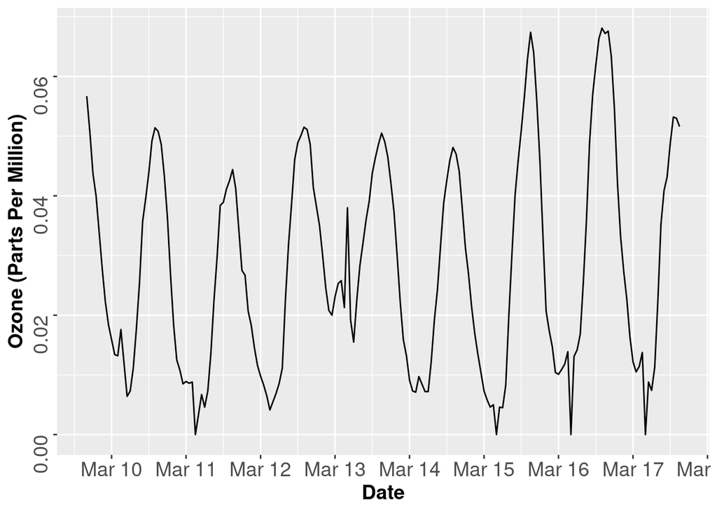

```r
## Plot Ozone Data for this Time Period
ozone_ts = ggplot(data = Ozone_CO2_Combined, mapping = aes(x = Date.Time, y = Sample.Measurement)) +
  geom_line() +
  labs(x = "Date", y = "Ozone (Parts Per Million)") +
  #labs(title = "Average Ozone PPM Across L.A. \nMeasured in Parts Per Milllion\nHourly, March 9th - March 16th 2014") +
  scale_x_datetime(breaks = scales::breaks_pretty(12)) +
  theme(text = element_text(size = 20),
    legend.title = element_text(size = 10),
    legend.text = element_text(size = 10),
    legend.key.width=unit(1,"cm"),
    axis.text.y = element_text(angle=90, hjust=1, size = 14),
    axis.text.x = element_text(size = 14),
    plot.title = element_text(hjust = 0.5, size = 12),
    axis.title=element_text(size=14,face="bold"))

## Plots for report
#png(filename = "Images/Ozone_TS_Plot.png", width = 960, height = 480)
ozone_ts
```

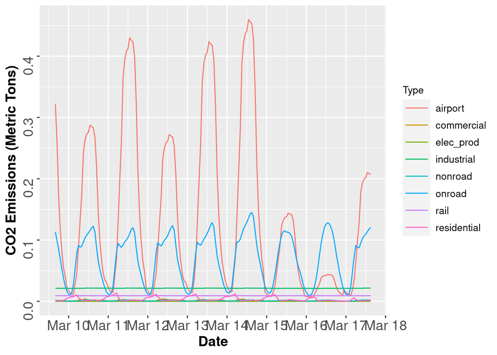

```r
#dev.off()


## Plot CO2 Data for this Time Period, Not Scaled
co2_unscaled_plot = ggplot(data = Ozone_CO2_Combined_Long, aes(x = Date.Time, y = CO2, color = Type)) +
  geom_line() +
  labs(x = "Date", y = "CO2 Emissions (Metric Tons)") +
  #labs(title = "Average CO2 Across L.A. Sensors\nMeasured in Metric Tons\nHourly, March 9th - March 16th 2014") +
  scale_x_datetime(breaks = scales::breaks_pretty(12)) +
  theme(text = element_text(size = 20),
    legend.title = element_text(size = 10),
    legend.text = element_text(size = 10),
    legend.key.width=unit(1,"cm"),
    axis.text.y = element_text(angle=90, hjust=1, size = 14),
    axis.text.x = element_text(size = 14),
    plot.title = element_text(hjust = 0.5, size = 12),
    axis.title=element_text(size=14,face="bold"))

## Plot for report
#png(filename = "Images/CO2_TS_Plot_Not_Scaled.png", width = 960, height = 480)
co2_unscaled_plot
```

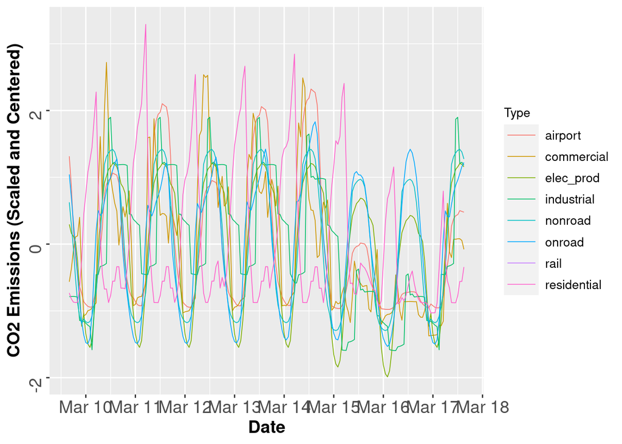

```r
#dev.off()

## Plot CO2 Data for this Time Period, Not Scaled
co2_scaled_plot = ggplot(data = Ozone_CO2_Combined_Long_Scaled, aes(x = Date.Time, y = CO2, color = Type)) +
  geom_line(size = .3) +
  labs(x = "Date", y = "CO2 Emissions (Scaled and Centered)") +
  #labs(title = "Average CO2 Across L.A. Sensors\nMeasured in Metric Tons\nHourly, March 9th - March 16th 2014") +
  scale_x_datetime(breaks = scales::breaks_pretty(12)) +
  theme(text = element_text(size = 20),
    legend.title = element_text(size = 10),
    legend.text = element_text(size = 10),
    legend.key.width=unit(1,"cm"),
    axis.text.y = element_text(angle=90, hjust=1, size = 14),
    axis.text.x = element_text(size = 14),
    plot.title = element_text(hjust = 0.5, size = 12),
    axis.title=element_text(size=14,face="bold"))

## Plot for report
#png(filename = "Images/CO2_TS_Plot_Scaled.png", width = 960, height = 480)
co2_scaled_plot
```

```r
#dev.off()


remove(ozone_ts,co2_unscaled_plot,co2_scaled_plot)
```

### ACFs and PACFs for Ozone

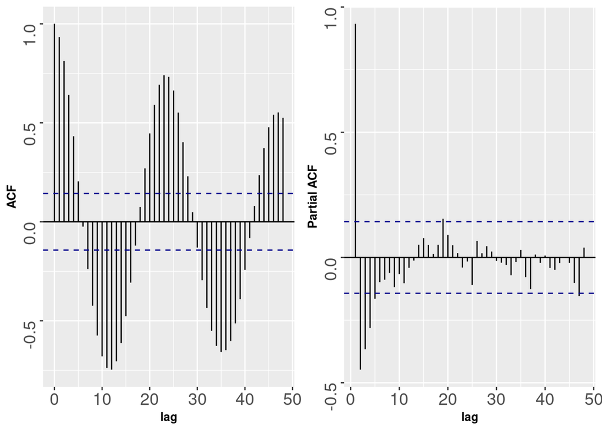

```r
## Sample ACF
ozone_acf_list = acf(Ozone_CO2_Combined$Sample.Measurement, plot = FALSE, lag.max = 48)

# Put into Dataframe
ozone_acf = as.data.frame(do.call(cbind, ozone_acf_list))

# Confidence Interval Line
conf.level = 0.95
ciline = qnorm((1 - conf.level)/2)/sqrt(length(Ozone_CO2_Combined$Sample.Measurement))

# Plot
ACF_Ozone_Graph = ggplot(data = ozone_acf, mapping = aes(x = as.numeric(lag), y = as.numeric(acf))) +
  geom_hline(aes(yintercept = 0)) +
  geom_segment(mapping = aes(xend = as.numeric(lag), yend = 0)) +
  geom_hline(aes(yintercept = ciline), linetype = 2, color = 'darkblue') +
  geom_hline(aes(yintercept = -ciline), linetype = 2, color = 'darkblue') +
  labs(x = "lag", y = "ACF") +
  theme(text = element_text(size = 20),
    legend.title = element_text(size = 10),
    legend.text = element_text(size = 10),
    legend.key.width=unit(1,"cm"),
    axis.text.y = element_text(angle=90, hjust=1, size = 14),
    axis.text.x = element_text(size = 14),
    plot.title = element_text(hjust = 0.5, size = 12),
    axis.title=element_text(size=10,face="bold"))


## Sample PACF
ozone_pacf_list = pacf(Ozone_CO2_Combined$Sample.Measurement, plot = FALSE, lag.max = 48)

# Put into Dataframe
ozone_pacf = as.data.frame(do.call(cbind, ozone_pacf_list))

# Plot
PACF_Ozone_Graph = ggplot(data = ozone_pacf, mapping = aes(x = as.numeric(lag), y = as.numeric(acf))) +
  geom_hline(aes(yintercept = 0)) +
  geom_segment(mapping = aes(xend = as.numeric(lag), yend = 0)) +
  geom_hline(aes(yintercept = ciline), linetype = 2, color = 'darkblue') +
  geom_hline(aes(yintercept = -ciline), linetype = 2, color = 'darkblue') +
  labs(x = "lag", y = "Partial ACF") +
  theme(text = element_text(size = 20),
    legend.title = element_text(size = 10),
    legend.text = element_text(size = 10),
    legend.key.width=unit(1,"cm"),
    axis.text.y = element_text(angle=90, hjust=1, size = 14),
    axis.text.x = element_text(size = 14),
    plot.title = element_text(hjust = 0.5, size = 12),
    axis.title=element_text(size=10,face="bold"))

## Plots for Report
#png(filename = "Images/acf_pacf_ozone.png", width = 960, height = 480)
plot_grid(ACF_Ozone_Graph,PACF_Ozone_Graph, labels = NULL, label_size = 12, ncol = 2, nrow = 1)
```

```r
#dev.off()

remove(ozone_acf_list,ozone_acf,conf.level,ciline,ACF_Ozone_Graph,
       ozone_pacf_list,ozone_pacf,PACF_Ozone_Graph)
```

### ACFs and PACFs for Airport

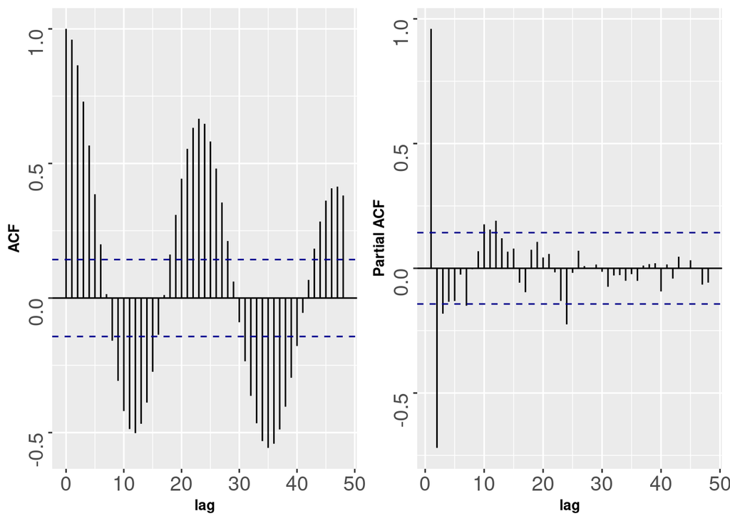

```r
## Sample ACF
airport_acf_list = acf(Ozone_CO2_Combined$airport, plot = FALSE, lag.max = 48)

# Put into Dataframe
airport_acf = as.data.frame(do.call(cbind, airport_acf_list))

# Confidence Interval Line
conf.level = 0.95
ciline = qnorm((1 - conf.level)/2)/sqrt(length(Ozone_CO2_Combined$airport))

# Plot
ACF_Airport_Graph = ggplot(data = airport_acf, mapping = aes(x = as.numeric(lag), y = as.numeric(acf))) +
  geom_hline(aes(yintercept = 0)) +
  geom_segment(mapping = aes(xend = as.numeric(lag), yend = 0)) +
  geom_hline(aes(yintercept = ciline), linetype = 2, color = 'darkblue') +
  geom_hline(aes(yintercept = -ciline), linetype = 2, color = 'darkblue') +
  labs(x = "lag", y = "ACF") +
  theme(text = element_text(size = 20),
    legend.title = element_text(size = 10),
    legend.text = element_text(size = 10),
    legend.key.width=unit(1,"cm"),
    axis.text.y = element_text(angle=90, hjust=1, size = 14),
    axis.text.x = element_text(size = 14),
    plot.title = element_text(hjust = 0.5, size = 12),
    axis.title=element_text(size=10,face="bold"))


## Sample PACF
airport_pacf_list = pacf(Ozone_CO2_Combined$airport, plot = FALSE, lag.max = 48)

# Put into Dataframe
airport_pacf = as.data.frame(do.call(cbind, airport_pacf_list))

# Plot
PACF_Airport_Graph = ggplot(data = airport_pacf, mapping = aes(x = as.numeric(lag), y = as.numeric(acf))) +
  geom_hline(aes(yintercept = 0)) +
  geom_segment(mapping = aes(xend = as.numeric(lag), yend = 0)) +
  geom_hline(aes(yintercept = ciline), linetype = 2, color = 'darkblue') +
  geom_hline(aes(yintercept = -ciline), linetype = 2, color = 'darkblue') +
  labs(x = "lag", y = "Partial ACF") +
  theme(text = element_text(size = 20),
    legend.title = element_text(size = 10),
    legend.text = element_text(size = 10),
    legend.key.width=unit(1,"cm"),
    axis.text.y = element_text(angle=90, hjust=1, size = 14),
    axis.text.x = element_text(size = 14),
    plot.title = element_text(hjust = 0.5, size = 12),
    axis.title=element_text(size=10,face="bold"))

## Plots for Report
#png(filename = "Images/acf_pacf_airport.png", width = 960, height = 480)
plot_grid(ACF_Airport_Graph,PACF_Airport_Graph, labels = NULL, label_size = 12, ncol = 2, nrow = 1)
```

```r
#dev.off()

remove(airport_acf_list,airport_acf,conf.level,ciline,ACF_Airport_Graph,airport_pacf_list,airport_pacf,PACF_Airport_Graph)
```

### ACFs and PACFs for Residential

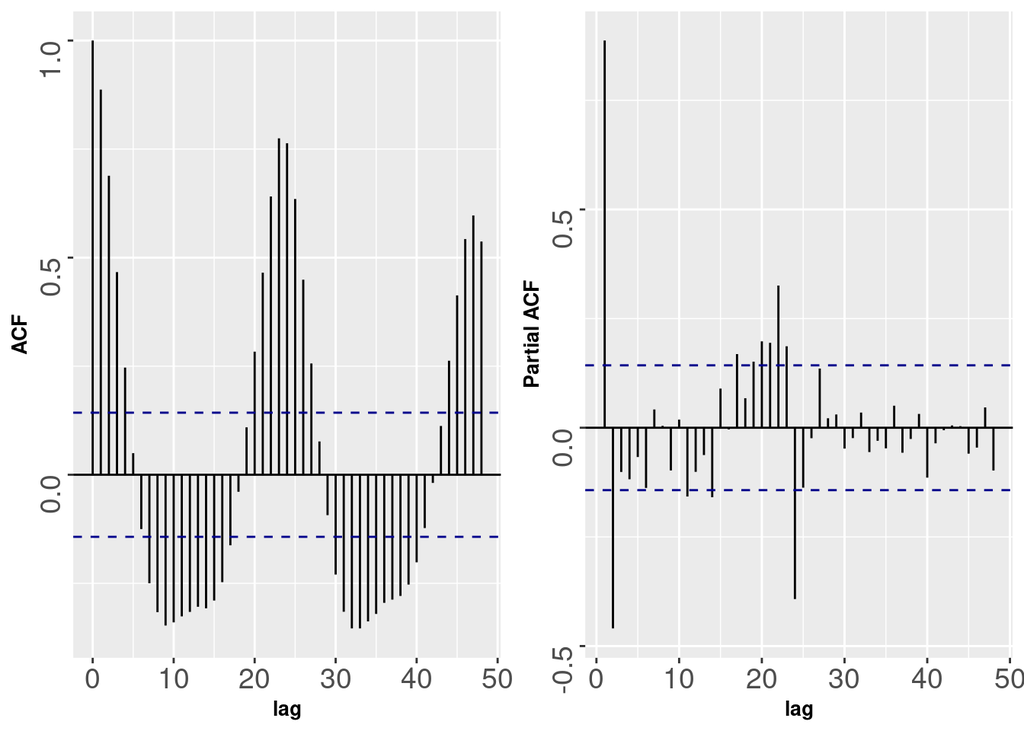

```r
## Sample ACF
residential_acf_list = acf(Ozone_CO2_Combined$residential, plot = FALSE, lag.max = 48)

# Put into Dataframe
residential_acf = as.data.frame(do.call(cbind, residential_acf_list))

# Confidence Interval Line
conf.level = 0.95
ciline = qnorm((1 - conf.level)/2)/sqrt(length(Ozone_CO2_Combined$residential))

# Plot
ACF_Residential_Graph = ggplot(data = residential_acf, mapping = aes(x = as.numeric(lag), y = as.numeric(acf))) +
  geom_hline(aes(yintercept = 0)) +
  geom_segment(mapping = aes(xend = as.numeric(lag), yend = 0)) +
  geom_hline(aes(yintercept = ciline), linetype = 2, color = 'darkblue') +
  geom_hline(aes(yintercept = -ciline), linetype = 2, color = 'darkblue') +
  labs(x = "lag", y = "ACF") +
  theme(text = element_text(size = 20),
    legend.title = element_text(size = 10),
    legend.text = element_text(size = 10),
    legend.key.width=unit(1,"cm"),
    axis.text.y = element_text(angle=90, hjust=1, size = 14),
    axis.text.x = element_text(size = 14),
    plot.title = element_text(hjust = 0.5, size = 12),
    axis.title=element_text(size=10,face="bold"))


## Sample PACF
residential_pacf_list = pacf(Ozone_CO2_Combined$residential, plot = FALSE, lag.max = 48)

# Put into Dataframe
residential_pacf = as.data.frame(do.call(cbind, residential_pacf_list))

# Plot
PACF_Residential_Graph = ggplot(data = residential_pacf, mapping = aes(x = as.numeric(lag), y = as.numeric(acf))) +
  geom_hline(aes(yintercept = 0)) +
  geom_segment(mapping = aes(xend = as.numeric(lag), yend = 0)) +
  geom_hline(aes(yintercept = ciline), linetype = 2, color = 'darkblue') +
  geom_hline(aes(yintercept = -ciline), linetype = 2, color = 'darkblue') +
  labs(x = "lag", y = "Partial ACF") +
  theme(text = element_text(size = 20),
    legend.title = element_text(size = 10),
    legend.text = element_text(size = 10),
    legend.key.width=unit(1,"cm"),
    axis.text.y = element_text(angle=90, hjust=1, size = 14),
    axis.text.x = element_text(size = 14),
    plot.title = element_text(hjust = 0.5, size = 12),
    axis.title=element_text(size=10,face="bold"))

## Plots for Report
#png(filename = "Images/acf_pacf_residential.png", width = 960, height = 480)
plot_grid(ACF_Residential_Graph,PACF_Residential_Graph, labels = NULL, label_size = 12, ncol = 2, nrow = 1)
```

```r
#dev.off()

remove(residential_acf_list,residential_acf,conf.level,ciline,ACF_Residential_Graph,residential_pacf_list,residential_pacf,PACF_Residential_Graph)
```

### CCF for Ozone vs Airport and Residential

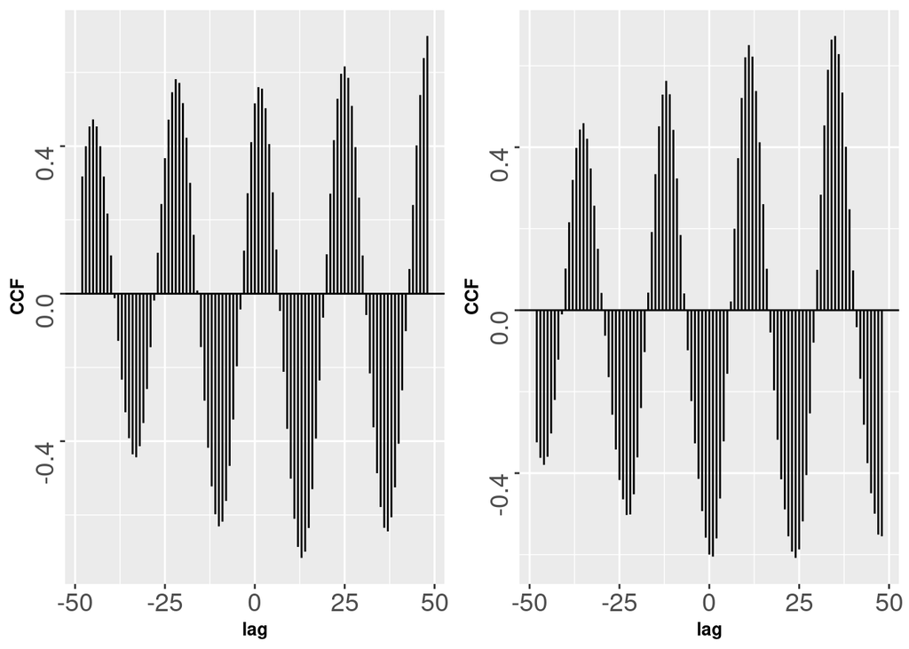

```r
## CCF Ozone Airport
ozone_airport_ccf_list = ccf(Ozone_CO2_Combined$Sample.Measurement,Ozone_CO2_Combined$airport, plot = FALSE, lag.max = 48,
                             type = "correlation")

# Put into Dataframe
ozone_airport_ccf = as.data.frame(do.call(cbind, ozone_airport_ccf_list))

# Plot
CCF_Ozone_Airport_Graph = ggplot(data = ozone_airport_ccf, mapping = aes(x = as.numeric(lag), y = as.numeric(acf))) +
  geom_hline(aes(yintercept = 0)) +
  geom_segment(mapping = aes(xend = as.numeric(lag), yend = 0)) +
  labs(x = "lag", y = "CCF") +
  theme(text = element_text(size = 20),
    legend.title = element_text(size = 10),
    legend.text = element_text(size = 10),
    legend.key.width=unit(1,"cm"),
    axis.text.y = element_text(angle=90, hjust=1, size = 14),
    axis.text.x = element_text(size = 14),
    plot.title = element_text(hjust = 0.5, size = 12),
    axis.title=element_text(size=10,face="bold"))


## CCF Ozone Residential
ozone_residential_ccf_list = ccf(Ozone_CO2_Combined$Sample.Measurement,Ozone_CO2_Combined$residential, plot = FALSE, lag.max = 48,
                             type = "correlation")

# Put into Dataframe
ozone_residential_ccf = as.data.frame(do.call(cbind, ozone_residential_ccf_list))

# Plot
CCF_Ozone_Residential_Graph = ggplot(data = ozone_residential_ccf, mapping = aes(x = as.numeric(lag), y = as.numeric(acf))) +
  geom_hline(aes(yintercept = 0)) +
  geom_segment(mapping = aes(xend = as.numeric(lag), yend = 0)) +
  labs(x = "lag", y = "CCF") +
  theme(text = element_text(size = 20),
    legend.title = element_text(size = 10),
    legend.text = element_text(size = 10),
    legend.key.width=unit(1,"cm"),
    axis.text.y = element_text(angle=90, hjust=1, size = 14),
    axis.text.x = element_text(size = 14),
    plot.title = element_text(hjust = 0.5, size = 12),
    axis.title=element_text(size=10,face="bold"))



## Plots for Report
# Uncomment the code to output the plots
#png(filename = "Images/ccf_ozone_airport_residential.png", width = 960, height = 480)
plot_grid(CCF_Ozone_Airport_Graph,CCF_Ozone_Residential_Graph, labels = NULL, label_size = 12, ncol = 2, nrow = 1)
```

```r
#dev.off()

remove(ozone_airport_ccf_list,ozone_airport_ccf,CCF_Ozone_Airport_Graph,
       ozone_residential_ccf_list,ozone_residential_ccf,CCF_Ozone_Residential_Graph)
```

# PCA Methods

Analysis regardin PCA is performed in the following sections.

### Prepare Data

The X matrix is the CO2 data for airport, commercial, electricity production, industrial, nonroad, onroad, and residential. Rail is excluded as it is invariate across the period. CMV and Cement where not reported for the sensors for the specified dates and geographic location.

The data is scaled and centered, which is typical for PCA.

```r
# Create Matrices
X_Matrix = model_data[,2:ncol(model_data)]
Y_Matrix = as.matrix(model_data[,1])

# Get Column of Hours
X_hours = hour(Ozone_CO2_Combined$Date.Time)

# Center and Scale Data
X_scale_center = scale(X_Matrix,scale = TRUE, center = TRUE)

# Clean Environment
remove(CO2_Long_V1, Ozone_CO2_Combined_Long, Ozone_CO2_Combined_Long_Scaled)
```

The following sections perform PCA via a number of methods, as discussed in the report. Each method is repeated 1000 times as each iteration can randomly fluctuate based on the machine running it (the metric is processing time on the machine).

### PCA using Base R (Stats Package)

```r
## Use prcomp function To Get PC and Projection
# Measure Computational Time - 1000 Iterations
time_prcomp_pca = data.frame(time = rep(NA,1000),method = rep("prcomp",1000))
for (i in 1:1000) {
  start = Sys.time()

  # PR Comp Function. To be consistent with other methods,
  # Use the already scaled and centered version
  prcomp_pca = prcomp(X_scale_center,scale = FALSE, center = FALSE)

  # Measure Time
  end = Sys.time()
  time_prcomp_pca[i,1] = end-start
  remove(start,end,prcomp_pca)
}

# Rename/Extract PC and Project Matrices
prcomp_pca = prcomp(X_scale_center,scale = FALSE, center = FALSE)
prcomp_pc = prcomp_pca$x
prcomp_proj = prcomp_pca$rotation
```

### PCA Using Eigenvalue Decomposition

```r
## Use eigen Function in R to get PC and Projection
# Measure Computational Time - 1000 iterations
time_eigen_pca = data.frame(time = rep(NA,1000),method = rep("eigen",1000))
for (i in 1:1000) {
  start = Sys.time()

  # Calculate Covariance Matrix of Centered and scaled data
  C = t(X_scale_center)%*%X_scale_center

  # Use eigen function to get eigen vectors of C
  # Innerproduct of X and eigenvectors to get principal components
  eigen_pc = X_scale_center%*%eigen(C)$vectors

  # Measure Time
  end = Sys.time()
  time_eigen_pca[i,1] = end-start
  remove(start,end,C,eigen_pc)
}

# The projection matrix is just the eigenvectors
# Excluding this from computation time since it
# is not a necessary step (just renaming values
# For consistency)
C = t(X_scale_center)%*%X_scale_center
eigen_pc = X_scale_center%*%eigen(C)$vectors
eigen_proj = eigen(C)$vectors

# Extract Eigenvalues as well
eigen_C_values = eigen(C)$values
```

### PCA Using Singular Value Decomp

```r
## Use svd Function in R to get PC and Projection
# Measure Computational Time - 1000 iterations
time_svd_pca = data.frame(time = rep(NA,1000),method = rep("svd",1000))
for (i in 1:1000) {
  start = Sys.time()

  # Perform SVD Using R Function
  X_svd = svd(X_scale_center)

  # Get Principal Compents by m
  svd_pc = X_svd$u%*%diag(X_svd$d)

  # Measure Time
  end = Sys.time()
  time_svd_pca[i,1] = end-start
  remove(start,end,X_svd,svd_pc)
}

# Extract Values
X_svd = svd(X_scale_center)
svd_pc = X_svd$u%*%diag(X_svd$d)
svd_singular_values = X_svd$d
svd_eigenvalues = svd_singular_values^2
svd_proj = X_svd$v
```

### PCA Using NIPALS Algorithm

```r
# Set Seed for Reproducibility (to randomly set t)
set.seed(42)

## Use Nipals Algorithm in R to get PC and Projection
# Measure Computational Time - 1000 iterations
time_nipals_pca = data.frame(time = rep(NA,1000),method = rep("nipals",1000))
for (j in 1:1000) {
  start = Sys.time()

  # Initialize T and P matrices
  n = nrow(X_scale_center)
  p = ncol(X_scale_center)
  T = matrix(NA, nrow = n, ncol = p)
  P = matrix(NA, nrow = p, ncol = p)

  # Initialize Raw data Matrix as scaled, centered matrix
  X = X_scale_center

  # Choose Threshold for convergence
  epsilon = .000000001
  # Initialize to something greater than epsilon
  e = 1
  # Counter to see how many iterations it takes for convergence
  counter = 0

  # Step 1: Initialize t
  t_vec = matrix(rnorm(n,0,1),byrow = TRUE)

  for (i in 1:ncol(X)){
    # Loop for Component
    while(e > epsilon) {

      # Check how many loops occur
      counter = counter + 1

      # Step 2: Calculate p vector
      p_prime = t((t(t_vec)%*%X)*(as.numeric(1/(t(t_vec)%*%t_vec))))

      # Step 3: Rescale Loading Vector
      p_prime = p_prime*(as.numeric(1/sqrt(t(p_prime)%*%p_prime)))

      # Step 4: Regress X onto Normalized Loading Vector
      t_vec_new = X%*%p_prime*(as.numeric(1/t(p_prime)%*%p_prime))

      # Step 5: Check for Difference between t_vec and t_vec_new
      e = sum((t_vec - t_vec_new)^2)
      t_vec = t_vec_new
    }

    # Step 6: Save Score and Loading vectors and deflate X
    T[,i] = t_vec
    P[,i] = p_prime
    # Deflate X
    X = X - t_vec%*%t(p_prime)

    # Reset e
    e = 1
  }

  # Measure Time
  end = Sys.time()
  time_nipals_pca[j,1] = end-start

  # Extract Values
  nipals_pc = T
  nipals_proj = P

  remove(start,end,n,p,T,P,X,epsilon,e,
         counter,p_prime,t_vec,t_vec_new)
}
```

### PCA via Kernlab Package (Linear Kernel)

Note that the kernlab PCA, via vallidot kernel, was actually not found to be the same as the other methods. I am not sure why this is occuring: I don't believe any parameters (such as some scalar) are being provided.

```r
## Use the kernlab package and linear kernel to get PC
# Measure Computational Time - 1000 iterations
time_kernlab_pca = data.frame(time = rep(NA,1000),method = rep("kernlab",1000))
for (i in 1:1000){
  start = Sys.time()

  # Linear Kernel, Same as Regular PCA
  kpca_kernlab_linear = kpca(~.,as.data.frame(X_scale_center),kernel="vanilladot",
              kpar=list(),features=7)

  # Measure Time
  end = Sys.time()
  time_kernlab_pca[i,1] = end-start
  remove(start,end,kpca_kernlab_linear)

}

# Extract/Rename values
kpca_kernlab_linear = kpca(~.,as.data.frame(X_scale_center),kernel="vanilladot",
            kpar=list(),features=7)
kernlab_pc = pcv(kpca_kernlab_linear)
kernlab_proj = rotated(kpca_kernlab_linear)
```

### Plot Histograms of Processing time

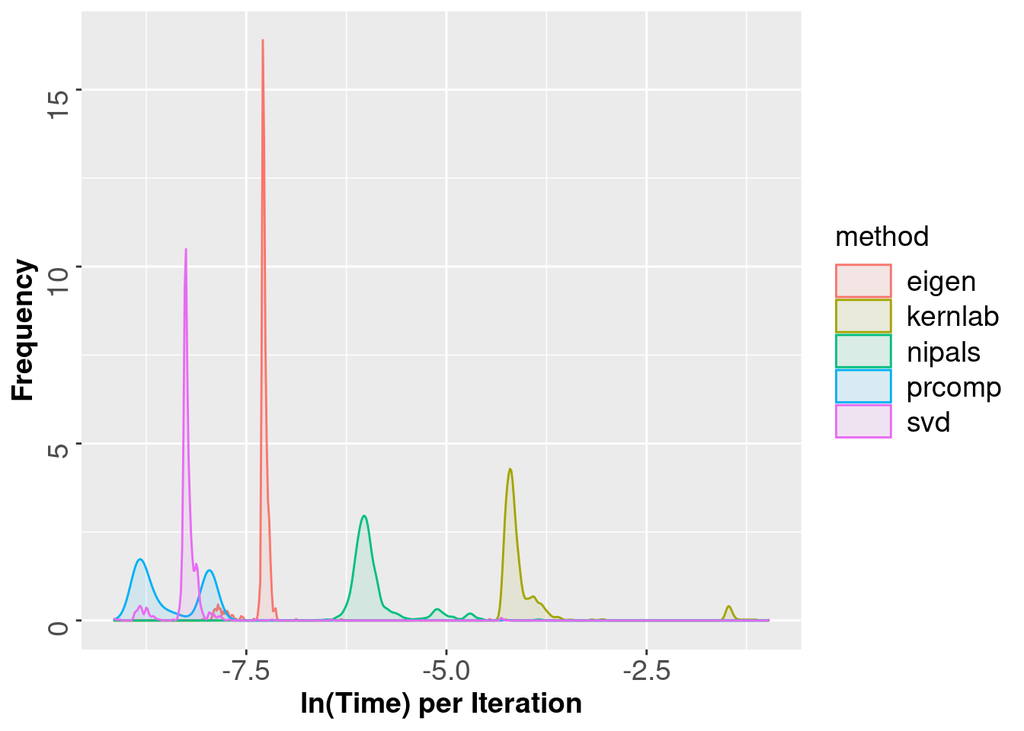

```r
# Create Dataframe for Plotting
comp_df = rbind(time_prcomp_pca,time_eigen_pca,
                time_svd_pca,time_kernlab_pca,time_nipals_pca)

# Histogram for Single Variable
computational_time_density_plot =
  ggplot(comp_df, aes(x = log(time), color = method, fill = method)) +
  geom_density(alpha = 0.1) +
  labs(x = "ln(Time) per Iteration", y = "Frequency") +
  theme(text = element_text(size = 20),
    legend.title = element_text(size = 14),
    legend.text = element_text(size = 14),
    legend.key.width=unit(1,"cm"),
    axis.text.y = element_text(angle=90, hjust=1, size = 14),
    axis.text.x = element_text(size = 14),
    axis.title=element_text(size=14,face="bold"))

## Plot for report
#png(filename = "Images/PCA_Computational_Time.png", width = 960, height = 480)
computational_time_density_plot
```

```r
#dev.off()
```

### Confirm Methods produce same Principal Components

```r
# Confirm Same Principal Components
sum(abs(prcomp_pc)-abs(eigen_pc))
```

```
## [1] -7.327472e-14
```

```r
sum(abs(prcomp_pc)-abs(svd_pc))
```

```
## [1] -3.040684e-13
```

```r
sum(abs(prcomp_pc)-abs(nipals_pc))
```

```
## [1] 0.0006407625
```

```r
# Not the same, needs inspection
sum(abs(prcomp_pc)-abs(xmatrix(kpca_kernlab_linear)))
```

```
## [1] -288.3569
```

```r
# Clean Environment
remove(C, comp_df, computational_time_density_plot, eigen_pc,
       eigen_proj, kernlab_pc, kernlab_proj, kpca_kernlab_linear,
       nipals_pc, nipals_proj, prcomp_pc, prcomp_proj,
       time_eigen_pca, time_kernlab_pca, time_nipals_pca,
       time_prcomp_pca, time_svd_pca, eigen_C_values, i, j,
       svd_singular_values, X_svd)
```

### Scree Plot

Below is the scree plot for this principal component analysis. The results are discussed in detail in the report

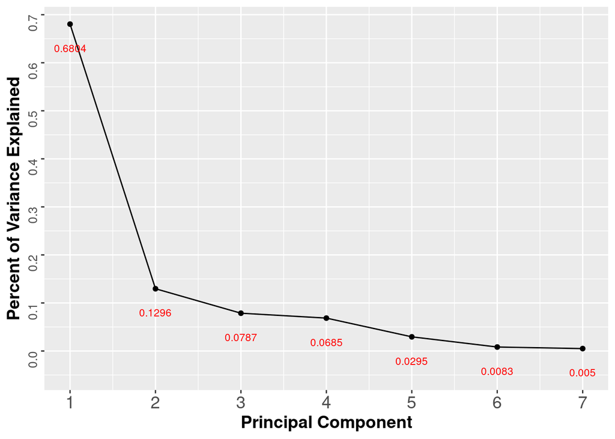

```r
# Percent of Variance Explained
percent_variance_explained =
  data.frame(PC = seq(1,7,by=1),
             Percent_Variance = (svd_eigenvalues / sum(svd_eigenvalues)))

# Create Scree Plot
pca_scree = ggplot(data = percent_variance_explained, aes(x = PC, y = Percent_Variance)) +
  geom_point() +
  geom_line() +
  geom_text(aes(label = round(Percent_Variance,4)), size = 3, color = "red", nudge_y = -.05) +
  scale_y_continuous(breaks = seq(0,.7,by = .1)) +
  scale_x_continuous(breaks = seq(1,7,by = 1)) +
  labs(x = "Principal Component", y = "Percent of Variance Explained") +
  theme(text = element_text(size = 20),
    legend.title = element_text(size = 14),
    legend.text = element_text(size = 14),
    legend.key.width=unit(1,"cm"),
    axis.text.y = element_text(angle=90, hjust=1, size = 10),
    axis.text.x = element_text(size = 14),
    axis.title=element_text(size=14,face="bold"))

## Plot for report
#png(filename = "Images/PCA_Scree_Plot.png", width = 720, height = 480)
pca_scree
```

```r
#dev.off()
```

### Biplot of Principal Components

Similarly, interpretation and the results of the biplots are discussed in detail in the paper report.

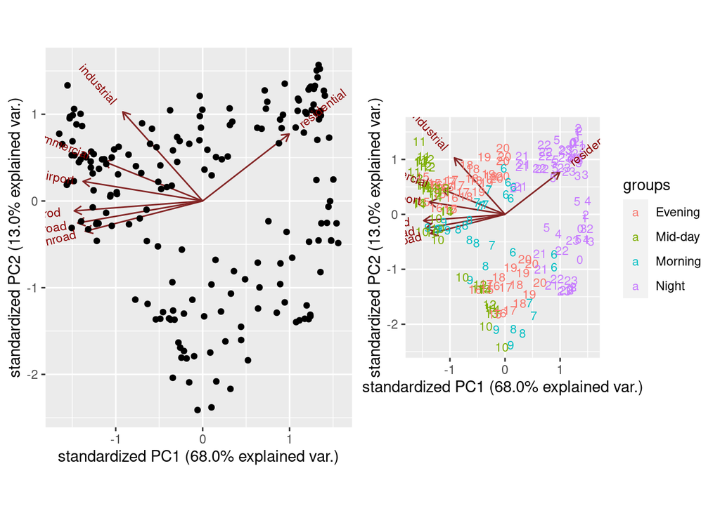

```r
## Using ggbiplot package designed for PC object


# Get Hours and Grouped Hours
X_hours_df = data.frame(hours = X_hours) %>%
  mutate(hour_group = ifelse(hours %in% c(21,22,23,0,1,2,3,4,5),"Night",
                             ifelse(hours %in% c(15,16,17,18,19,20),"Evening",
                                    ifelse(hours %in% c(6,7,8,9),"Morning","Mid-day"))))


# Plot 1: Just Loading Vectors
biplot_1_2_plain = ggbiplot(prcomp_pca)

# Plot 2: Loading Vectors and Grouping by time of day
biplot_1_2_groups = ggbiplot(prcomp_pca, labels=X_hours_df$hours, groups = X_hours_df$hour_group)

# Plot 3: Loading vectors with Ellipses for groups
biplot_1_2_groups_ellipses =
  ggbiplot(prcomp_pca, ellipse=TRUE,  labels=X_hours_df$hours, groups = X_hours_df$hour_group)

# Biplot of 3rd and 4th Principal Components
biplot_3_4_groups_ellipses = ggbiplot(prcomp_pca, choices=c(3,4), ellipse=TRUE,  labels=X_hours_df$hours, groups = X_hours_df$hour_group)


## Plots for Report
#png(filename = "Images/biplot_pc_1_2.png", width = 960, height = 480)
plot_grid(biplot_1_2_plain,biplot_1_2_groups, labels = NULL, label_size = 12, ncol = 2, nrow = 1)
```

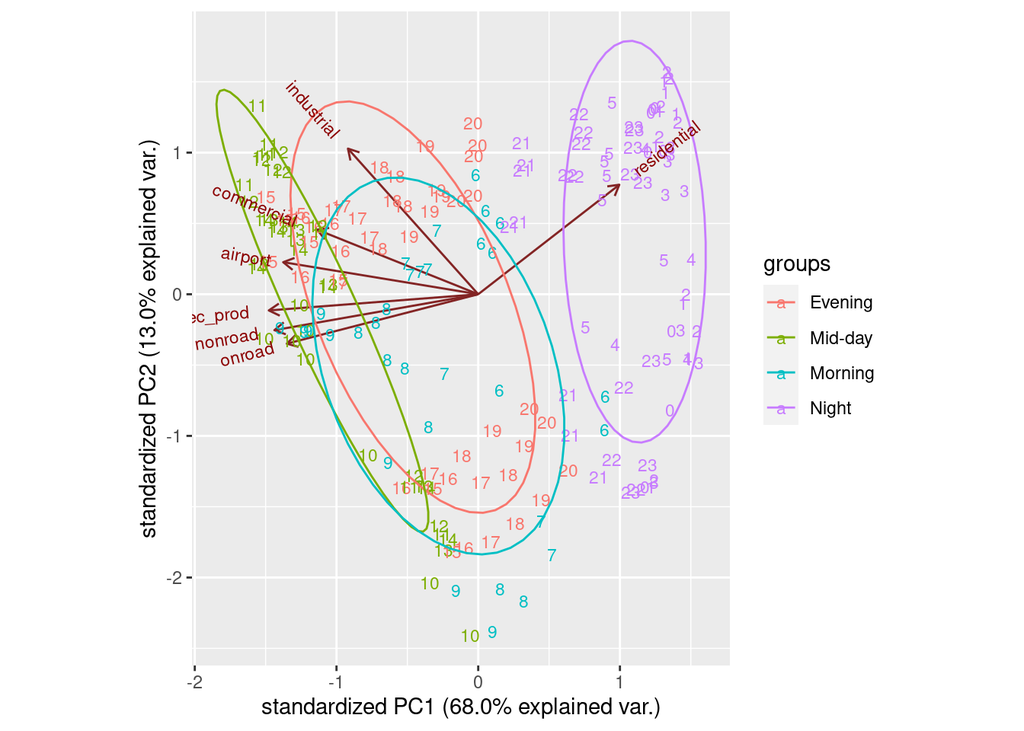

```r
#dev.off()

#png(filename = "Images/biplot_pc_1_2_detailed.png", width = 480, height = 480)
biplot_1_2_groups_ellipses
```

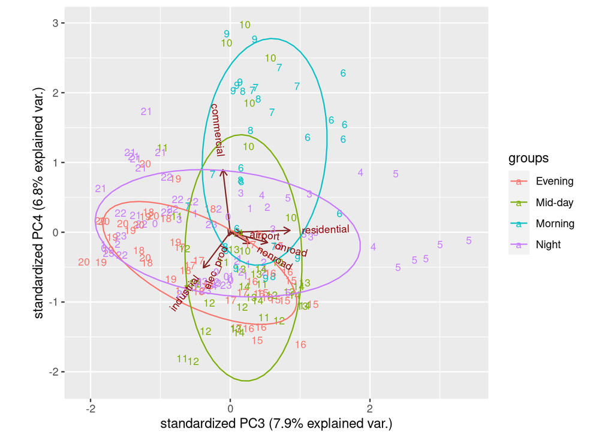

```r
#dev.off

#png(filename = "Images/biplot_pc_3_4.png", width = 480, height = 480)
biplot_3_4_groups_ellipses
```

```r
#dev.off

# Clean environment
remove(biplot_1_2_groups, biplot_1_2_groups_ellipses, biplot_1_2_plain,
       biplot_3_4_groups_ellipses)
```

### Principal Component Regression

```r
# Illustrate why PCR is Useful Here
model_linear_1 = lm(data = Ozone_CO2_Combined, Sample.Measurement ~
                      airport + commercial + elec_prod + industrial + nonroad + onroad + residential)

vif(model_linear_1)
```

```
##     airport  commercial   elec_prod  industrial     nonroad      onroad
##    4.699310    2.585385   17.484182    2.622725   12.543409   13.044841
## residential
##    2.739966
```

```r
## Alternatively, VIF for PC
# PCR Regression Using All Principal Componets
df_example = data.frame(cbind(Y_Matrix,svd_pc))
model_pc_example = lm(X1 ~ ., data = df_example)

vif(model_pc_example)
```

```
## X2 X3 X4 X5 X6 X7 X8
##  1  1  1  1  1  1  1
```

There are clear issues with the linear model and multicollinearity, as illustrated by the high VIFs of some of the variables

Below a linear model is fit for full set of principal components and a subset of four.

```r
# PCR Regression Using All Principal Componets
pcr_all_pc = lm(Y_Matrix ~ svd_pc - 1)
summary(pcr_all_pc)
```

```
##
## Call:
## lm(formula = Y_Matrix ~ svd_pc - 1)
##
## Residuals:
##      Min       1Q   Median       3Q      Max
## 0.004723 0.023107 0.027741 0.033949 0.056032
##
## Coefficients:
##           Estimate Std. Error t value Pr(>|t|)
## svd_pc1 -0.0055698  0.0010190  -5.466 1.51e-07 ***
## svd_pc2 -0.0057490  0.0023350  -2.462  0.01475 *
## svd_pc3  0.0001153  0.0029968   0.038  0.96935
## svd_pc4 -0.0097947  0.0032122  -3.049  0.00264 **
## svd_pc5 -0.0055338  0.0048945  -1.131  0.25971
## svd_pc6  0.0062286  0.0092260   0.675  0.50046
## svd_pc7 -0.0002916  0.0118629  -0.025  0.98041
## ---
## Signif. codes:  0 '***' 0.001 '**' 0.01 '*' 0.05 '.' 0.1 ' ' 1
##
## Residual standard error: 0.03041 on 181 degrees of freedom
## Multiple R-squared:  0.206,  Adjusted R-squared:  0.1753
## F-statistic:  6.71 on 7 and 181 DF,  p-value: 4.505e-07
```

```r
# PCR Regression Using 4 Principal Componets
pcr_4_pc = lm(Y_Matrix ~ svd_pc[,c(1:4)] - 1)
summary(pcr_4_pc)
```

```
##
## Call:
## lm(formula = Y_Matrix ~ svd_pc[, c(1:4)] - 1)
##
## Residuals:
##      Min       1Q   Median       3Q      Max
## 0.003477 0.022375 0.027631 0.034625 0.056429
##
## Coefficients:
##                     Estimate Std. Error t value Pr(>|t|)
## svd_pc[, c(1:4)]1 -0.0055698  0.0010155  -5.485 1.35e-07 ***
## svd_pc[, c(1:4)]2 -0.0057490  0.0023270  -2.471  0.01440 *
## svd_pc[, c(1:4)]3  0.0001153  0.0029865   0.039  0.96924
## svd_pc[, c(1:4)]4 -0.0097947  0.0032011  -3.060  0.00255 **
## ---
## Signif. codes:  0 '***' 0.001 '**' 0.01 '*' 0.05 '.' 0.1 ' ' 1
##
## Residual standard error: 0.03031 on 184 degrees of freedom
## Multiple R-squared:  0.1984, Adjusted R-squared:  0.181
## F-statistic: 11.39 on 4 and 184 DF,  p-value: 2.801e-08
```

Finally, PCR can also be done via the PLS package. The results are the same as performing PCA and then regressing on the Principal components, as is shown below.

```r
## PCR Regression Using PLS Package
# This portion just illustrates that PCR function
# can be used to achieve the same results
pca_regression_model = V1 ~ airport + commercial + elec_prod + industrial + nonroad + onroad + residential
pca_regression = pcr(pca_regression_model, data = as.data.frame(cbind(Y_Matrix,X_scale_center)))

# Illustrating that the coefficients from
# PCR package are the same as those produces when
# fitting the linear model, after those coefficients
# have been projected onto the subspace
pcr_all_pc$coefficients %*% t(svd_proj)
```

```
##              [,1]         [,2]       [,3]        [,4]       [,5]        [,6]
## [1,] -0.004524643 -0.006826822 0.00318092 0.003402554 0.01021876 0.004306309
##              [,7]
## [1,] -0.004217353
```

```r
pca_regression$coefficients[,,7]
```

```
##      airport   commercial    elec_prod   industrial      nonroad       onroad
## -0.004524643 -0.006826822  0.003180920  0.003402554  0.010218755  0.004306309
##  residential
## -0.004217353
```

```r
# Clean Environment
remove(pca_regression, pca_scree, pcr_4_pc, pcr_all_pc,
       percent_variance_explained, prcomp_pca, svd_pc,
       svd_proj, pca_regression_model, svd_eigenvalues,
       model_pc_example, model_linear_1, df_example)
```

# Kernel Methods

### Define Gram Matcies

```r
# Euclidean Distance Matrix Formula
#RBF: Define Euclidean Distance Matrix
euclidean_distance_function = function(M) {

  # Define Result Matrix for Outer Product
  result = matrix(NA,nrow = nrow(M),ncol = nrow(M))

  for(i in 1:nrow(M)) {
    for(j in 1:nrow(M)) {
      # Note: Taking sqrt to make proper
      # euclidean distance. Some kernels (rbf and
      # rq) then square the terms.
      # Could decrease computing time slightly
      # By not calculating true euclidean
      # distance here
      result[i,j] = sqrt(sum((M[i,] - M[j,])^2))
    }
  }
  # Return Result
  eu_matrix = result
  return(eu_matrix)
}


#Radial Basis Function Kernel
rbf_kernel = function(M, l) {

  # The euclidean distance matrix is squared
  # then multiplied by -sigma and exponentiated
  gram = exp(-1*(euclidean_distance_function(M)^2)/l)
  return(gram)
}

# Rational Quadratic Kernel
rq_kernel = function(M,l,alpha) {
  gram = (1 + ((euclidean_distance_function(M)^2)/(l*alpha)))^(-1*alpha)
  return(gram)
}

# Periodic Kernel
per_kernel = function(M,l,p) {
  gram = exp((-1)*sin(abs(euclidean_distance_function(M))*(pi/p))/l)
  return(gram)
}
```

### Calculate an Example value of the RBF Kernel

Choose l = 2

```r
# With user defined RBF Kernel
l = 2
user_kernel_rbf_2 = rbf_kernel(X_scale_center,l)

# Convert to data frame for plotting
user_kernel_rbf_2_df = user_kernel_rbf_2 %>%
  as.data.frame() %>%
  dplyr::mutate(xi = row_number()) %>%
  pivot_longer(starts_with("V"),names_to = "xj",values_to="Distance") %>%
  as.data.frame() %>%
  mutate(xj = as.numeric(str_remove(xj,"V")))

# Plot
user_kernel_rbf_2_plot = ggplot(data = user_kernel_rbf_2_df, aes(x=xi, y=xj, fill=Distance)) +
  geom_raster() +
  scale_fill_viridis_c() +
  scale_x_continuous(n.breaks = 10) +
  scale_y_continuous(n.breaks = 10) +
  labs(title = "User Defined RBF, l = 2, Kernel (Gram Matrix)") +
  theme_minimal()
```

### Calculate an Example value of the RBF Kernel Using Kernlab

Choosing l = 2. Note that the Kerlab package refers to this parameter as the "inverse kernel width." Trial and error appears to indicate this value is 1/l, as the RBF kernel is defined in this project (i.e. the parameter called "sigma" in the Kernlab documentation is in the numerator, not the demoninator)

```r
## initialize kernel function
l = 2
rbf = rbfdot(sigma = 1/l)

## calculate kernel matrix using Kernlab
kernlab_kernel_rbf_2 = kernelMatrix(rbf, X_scale_center)
# Convert to a data frame for plotting
kernlab_kernel_rbf_2_df = kernlab_kernel_rbf_2 %>%
  as.data.frame() %>%
  dplyr::mutate(xi = row_number()) %>%
  pivot_longer(starts_with("V"),names_to = "xj",values_to="Distance") %>%
  as.data.frame() %>%
  mutate(xj = as.numeric(str_remove(xj,"V")))

# Plot
kernlab_gram_rbf_2_plot = ggplot(data = kernlab_kernel_rbf_2_df, aes(x=xi, y=xj, fill=Distance)) +
  geom_raster() +
  scale_fill_viridis_c() +
  scale_x_continuous(n.breaks = 10) +
  scale_y_continuous(n.breaks = 10) +
  labs(title = "Kernlab Defined RBF, sigma = .5, Kernel (Gram Matrix)") +
  theme_minimal()
```

### Confirm the User defined kernel matches the kernlab version

There are some rounding differences likely from computation, but the below confirms that the kernels from the kernlab package (rbf specification) and the user defined function are the same.

```r
# Check that the values are effectively 0
max(kernlab_kernel_rbf_2 - user_kernel_rbf_2)
```

```
## [1] 2.664535e-15
```

```r
min(kernlab_kernel_rbf_2 - user_kernel_rbf_2)
```

```
## [1] -2.442491e-15
```

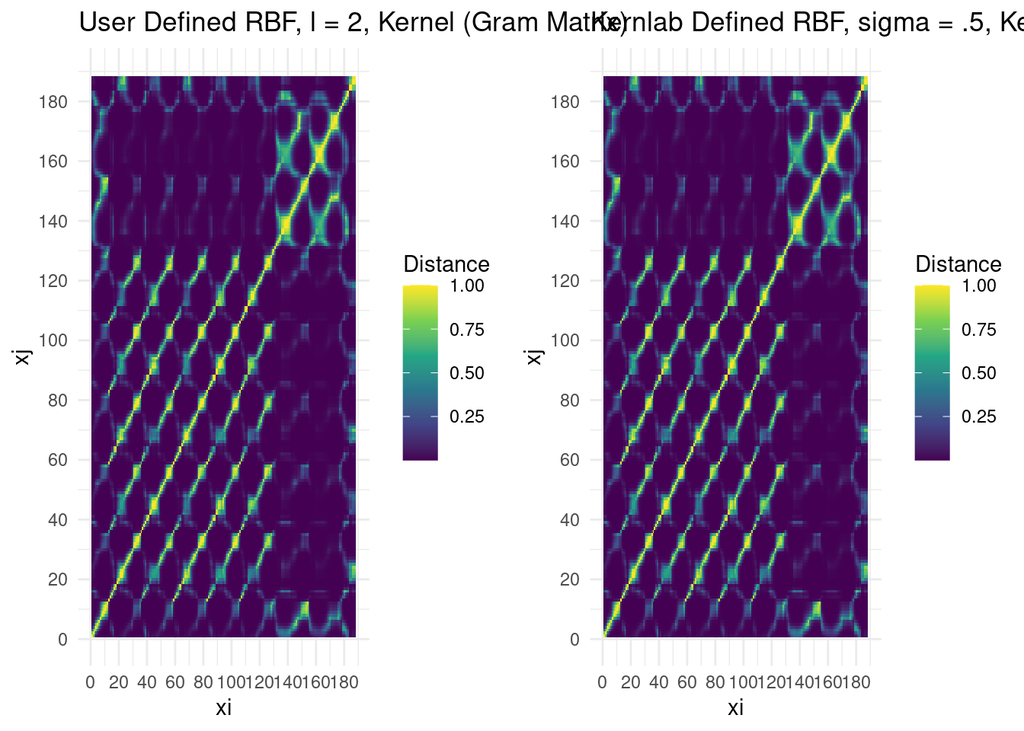

```r
# Plot both side by side
# remove comments to export the visual
#png(filename = "Images/check_gram_rbf_2.png", width = 1080, height = 480)
plot_grid(user_kernel_rbf_2_plot,kernlab_gram_rbf_2_plot, labels = NULL, label_size = 12, ncol = 2, nrow = 1)
```

```r
#dev.off()

remove(l, rbf, user_kernel_rbf_2_df, kernlab_kernel_rbf_2_df, user_kernel_rbf_2,
       kernlab_kernel_rbf_2, user_kernel_rbf_2_plot,kernlab_gram_rbf_2_plot)
```

### KPCA RBF Kernel: Exploring how Changes in l Effect Number of Principal Components

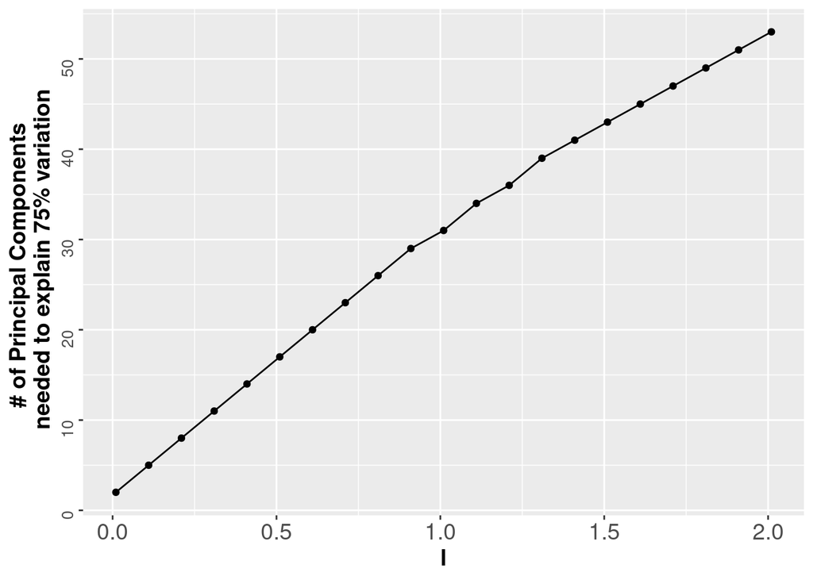

```r
## RBF, l = .01

## Note the kernlab package was used here. The "th" option  can be specificed in the kpca()
## function to allow for more PC and eigenvalues to be calculated. However, this section
## was sufficient in its currect form for the report and was left as is (e.g. th = 10^(-20))

# Note this section uses "sigma" and "l" interchangeably. The report sticks to "l"
# But some of the code was wirtten with "sigma" based on the definition in the
# kernlab package


# sigma is defined as the "inverse kernel width on Kernlab", i.e. is in the denominator
kpca_kernlab_rbf_01 = kpca(~.,as.data.frame(X_scale_center),kernel="rbfdot",
            kpar=list(sigma=.01))

kpcs_rbf_pc_01 = pcv(kpca_kernlab_rbf_01)
kpcs_rbf_eig_01 = eig(kpca_kernlab_rbf_01)

# Percent of Variance Explained
percent_variance_explained_rbf_01 =
  data.frame(PC = seq(1,length(kpcs_rbf_eig_01),by=1),
             Percent_Variance = (kpcs_rbf_eig_01 / sum(kpcs_rbf_eig_01)))

# Create Scree Plot
kpca_rbf_scree_01 = ggplot(data = percent_variance_explained_rbf_01, aes(x = PC, y = Percent_Variance)) +
  geom_point() +
  geom_line() +
  labs(x = "Principal Component", y = "Percent of Variance Explained") +
  theme(text = element_text(size = 20),
    legend.title = element_text(size = 14),
    legend.text = element_text(size = 14),
    legend.key.width=unit(1,"cm"),
    axis.text.y = element_text(angle=90, hjust=1, size = 10),
    axis.text.x = element_text(size = 14),
    axis.title=element_text(size=14,face="bold"))


## RBF, Sigma = 1
# sigma is defined as the "inverse kernel width on Kernlab", i.e. is in the denominator
kpca_kernlab_rbf_1 = kpca(~.,as.data.frame(X_scale_center),kernel="rbfdot",
            kpar=list(sigma=1))

kpcs_rbf_pc_1 = pcv(kpca_kernlab_rbf_1)
kpcs_rbf_eig_1 = eig(kpca_kernlab_rbf_1)

# Percent of Variance Explained
percent_variance_explained_rbf_1 =
  data.frame(PC = seq(1,length(kpcs_rbf_eig_1),by=1),
             Percent_Variance = (kpcs_rbf_eig_1 / sum(kpcs_rbf_eig_1)))

# Create Scree Plot
kpca_rbf_scree_1 = ggplot(data = percent_variance_explained_rbf_1, aes(x = PC, y = Percent_Variance)) +
  geom_point() +
  geom_line() +
  labs(x = "Principal Component", y = "Percent of Variance Explained") +
  theme(text = element_text(size = 20),
    legend.title = element_text(size = 14),
    legend.text = element_text(size = 14),
    legend.key.width=unit(1,"cm"),
    axis.text.y = element_text(angle=90, hjust=1, size = 10),
    axis.text.x = element_text(size = 14),
    axis.title=element_text(size=14,face="bold"))

## RBF, Sigma = 2
# sigma is defined as the "inverse kernel width on Kernlab", i.e. is in the denominator
kpca_kernlab_rbf_2 = kpca(~.,as.data.frame(X_scale_center),kernel="rbfdot",
            kpar=list(sigma=2))

kpcs_rbf_pc_2 = pcv(kpca_kernlab_rbf_2)
kpcs_rbf_eig_2 = eig(kpca_kernlab_rbf_2)

# Percent of Variance Explained
percent_variance_explained_rbf_2 =
  data.frame(PC = seq(1,length(kpcs_rbf_eig_2),by=1),
             Percent_Variance = (kpcs_rbf_eig_2 / sum(kpcs_rbf_eig_2)))

# Create Scree Plot
kpca_rbf_scree_2 = ggplot(data = percent_variance_explained_rbf_2, aes(x = PC, y = Percent_Variance)) +
  geom_point() +
  geom_line() +
  labs(x = "Principal Component", y = "Percent of Variance Explained") +
  theme(text = element_text(size = 20),
    legend.title = element_text(size = 14),
    legend.text = element_text(size = 14),
    legend.key.width=unit(1,"cm"),
    axis.text.y = element_text(angle=90, hjust=1, size = 10),
    axis.text.x = element_text(size = 14),
    axis.title=element_text(size=14,face="bold"))


## Measure relationship between l and number of PCs
# required to get to 75% of variance explained

# Define a list of sigmas to explore (l in project formula)
sigma_list = seq(.01,2.1,by = .1)

# Specify dataframe to add the number of PCs (technically loading vectors)
# necessary
rbf_df = data.frame(sigma = sigma_list, pc_count = rep(NA,length(sigma_list)))

# Counter for loop
counter = 0

# Loop over each value
for (i in sigma_list) {
  counter = counter + 1

  # Perform KPCA with the specified value of sigma
  kpca_kernlab_rbf = kpca(~.,as.data.frame(X_scale_center),kernel="rbfdot",
              kpar=list(sigma=i))

  # Calculate the cumulative variance, as provided
  # by the normalized eigenvalues
  cumeig = cumsum(eig(kpca_kernlab_rbf)/sum(eig(kpca_kernlab_rbf)))

  # Get the number of eigenvalues (i.e. PCs) necessary
  # to get to 75%
  number = length(cumeig[which(cumeig < .75)]) + 1

  #store the variable
  rbf_df[counter,2] = as.numeric(number)

  remove(kpca_kernlab_rbf,cumeig,number)
}

# Plot the Value of sigma by the variable
pca_count_plot_rbf = ggplot(data = rbf_df, aes(x = sigma, y = pc_count)) +
  geom_point() +
  geom_line() +
  labs(x = "l", y = "# of Principal Components \n needed to explain 75% variation") +
  theme(text = element_text(size = 20),
    legend.title = element_text(size = 14),
    legend.text = element_text(size = 14),
    legend.key.width=unit(1,"cm"),
    axis.text.y = element_text(angle=90, hjust=1, size = 10),
    axis.text.x = element_text(size = 14),
    axis.title=element_text(size=14,face="bold"))


# Save the output
# Remove comments to export the visual
#png(filename = "Images/rbf_varying_sigma.png", width = 960, height = 480)
pca_count_plot_rbf
```

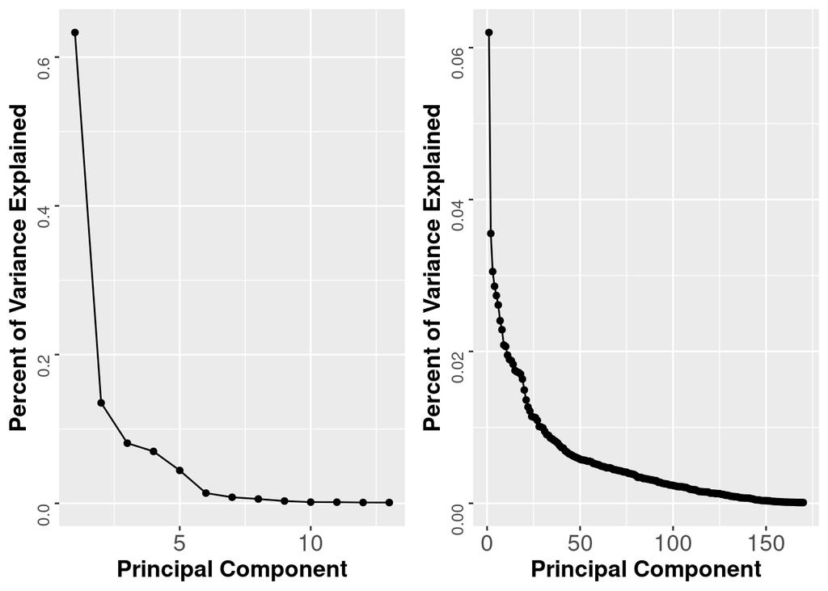

```r
#dev.off


# Plot scree plots side by side
# Remove comments to export the visual
#png(filename = "Images/rbf_sigma_01_and_2.png", width = 960, height = 480)
plot_grid(kpca_rbf_scree_01,kpca_rbf_scree_2, labels = NULL, label_size = 12, ncol = 2, nrow = 1)
```

```r
#dev.off()

# Clean environment
remove(counter, i, kpcs_rbf_eig_01,kpcs_rbf_eig_1, kpcs_rbf_eig_2,
       sigma_list, kpca_kernlab_rbf_01, kpca_kernlab_rbf_1,
       kpca_kernlab_rbf_2, kpca_rbf_scree_01, kpca_rbf_scree_1,
       kpca_rbf_scree_2,
       pca_count_plot_rbf, percent_variance_explained_rbf_01,
       percent_variance_explained_rbf_1, percent_variance_explained_rbf_2,
       rbf_df, kpcs_rbf_pc_01, kpcs_rbf_pc_1, kpcs_rbf_pc_2)
```

### KPCA RQ Kernel: Exploring Changes in l and alpha

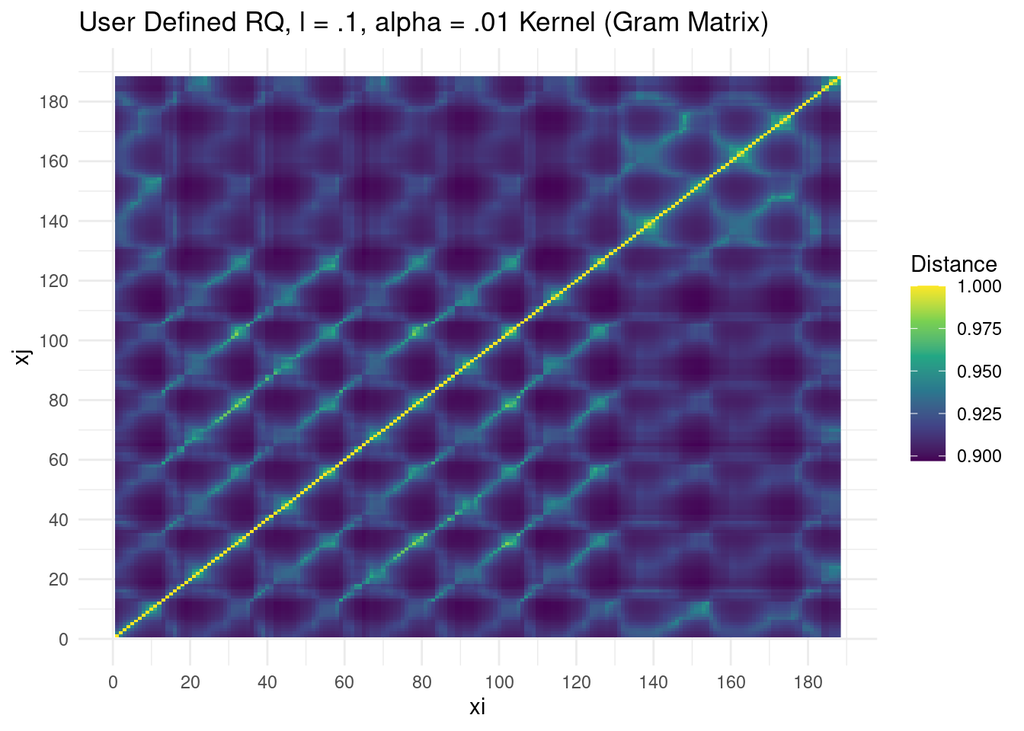

```r
## Generate RBF Kernel and Plot
# RQ, l = .1, alpha = .01
rq_gram_1_01 = rq_kernel(X_scale_center,.1,.01)

# Convert to data frame for plotting
user_kernel_rq_1_01_df = rq_gram_1_01 %>%
  as.data.frame() %>%
  dplyr::mutate(xi = row_number()) %>%
  pivot_longer(starts_with("V"),names_to = "xj",values_to="Distance") %>%
  as.data.frame() %>%
  mutate(xj = as.numeric(str_remove(xj,"V")))

# Plot
user_kernel_rq_1_01_plot = ggplot(data = user_kernel_rq_1_01_df, aes(x=xi, y=xj, fill=Distance)) +
  geom_raster() +
  scale_fill_viridis_c() +
  scale_x_continuous(n.breaks = 10) +
  scale_y_continuous(n.breaks = 10) +
  labs(title = "User Defined RQ, l = .1, alpha = .01 Kernel (Gram Matrix)") +
  theme_minimal()

# Export image for the report
# uncomment code to export the image
#png(filename = "Images/user_gram_rq_1_01.png", width = 480, height = 480)
user_kernel_rq_1_01_plot
```

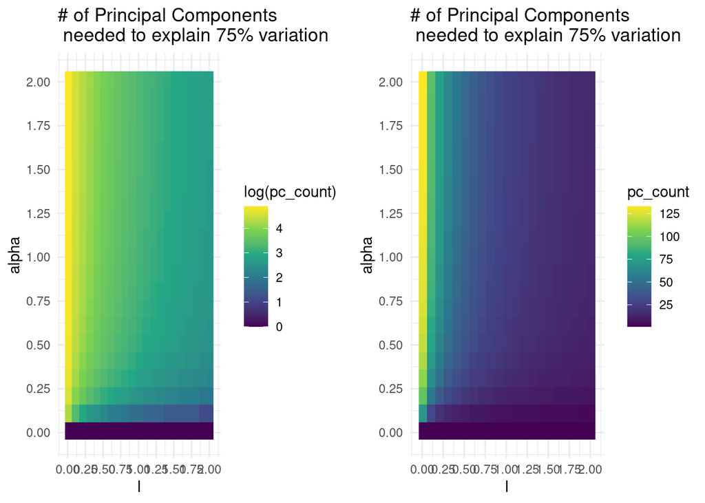

```r
#dev.off()



## Measure relationship between l and alpha and the number of PCs
# required to get to 75% of variance explained

# Define a list of l to explore
l_list = seq(.01,2.1,by = .1)
alpha_list = seq(.01,2.1,by = .1)

# Specify dataframe to add the number of PCs
# necessary
rq_df = data.frame(l = l_list, alpha = alpha_list)
rq_df = as.data.frame(expand(rq_df,l,alpha))
rq_df$pc_count = rep(NA,length(rq_df$l))

# Counter for loop
counter = 0

# Loop over each value
# Order matters here: depends on
# how df is constructed
for (l in l_list) {
  for (a in alpha_list) {
  counter = counter + 1

    # Calculate the Gram Matrix
    rq_gram = rq_kernel(X_scale_center,l,a)

    # Calculate the cumulative variance, as provided
    # by the normalized eigenvalues
    cumeig = cumsum(eigen(rq_gram)$values/sum(eigen(rq_gram)$values))

    # Get the number of eigenvalues (i.e. PCs) necessary
    # to get to 75%
    number = length(cumeig[which(cumeig < .75)]) + 1

    #store the variable
    rq_df[counter,3] = as.numeric(number)

    remove(rq_gram,cumeig,number)
  }
}

# Plot heatmap of l and alpha, with fill value being
pca_count_plot_rq_log = ggplot(data = rq_df, aes(x=l, y=alpha, fill=log(pc_count))) +
  geom_raster() +
  scale_fill_viridis_c() +
  scale_x_continuous(n.breaks = 10) +
  scale_y_continuous(n.breaks = 10) +
  labs(title = "# of Principal Components \n needed to explain 75% variation") +
  theme_minimal()

# Plot heatmap of l and alpha, with fill value being
pca_count_plot_rq = ggplot(data = rq_df, aes(x=l, y=alpha, fill=pc_count)) +
  geom_raster() +
  scale_fill_viridis_c() +
  scale_x_continuous(n.breaks = 10) +
  scale_y_continuous(n.breaks = 10) +
  labs(title = "# of Principal Components \n needed to explain 75% variation") +
  theme_minimal()


# Save the output
#png(filename = "Images/rq_varying_parameters.png", width = 1200, height = 480)
plot_grid(pca_count_plot_rq_log,pca_count_plot_rq, labels = NULL, label_size = 12, ncol = 2, nrow = 1)
```

```r
#dev.off

# Clean environment
remove(pca_count_plot_rq, pca_count_plot_rq_log, rq_df, rq_gram_1_01, user_kernel_rq_1_01_df,
       user_kernel_rq_1_01_plot,a, alpha_list, counter, l, l_list)
```

### KPCA PER Kernel: Exploring Changes in l and p

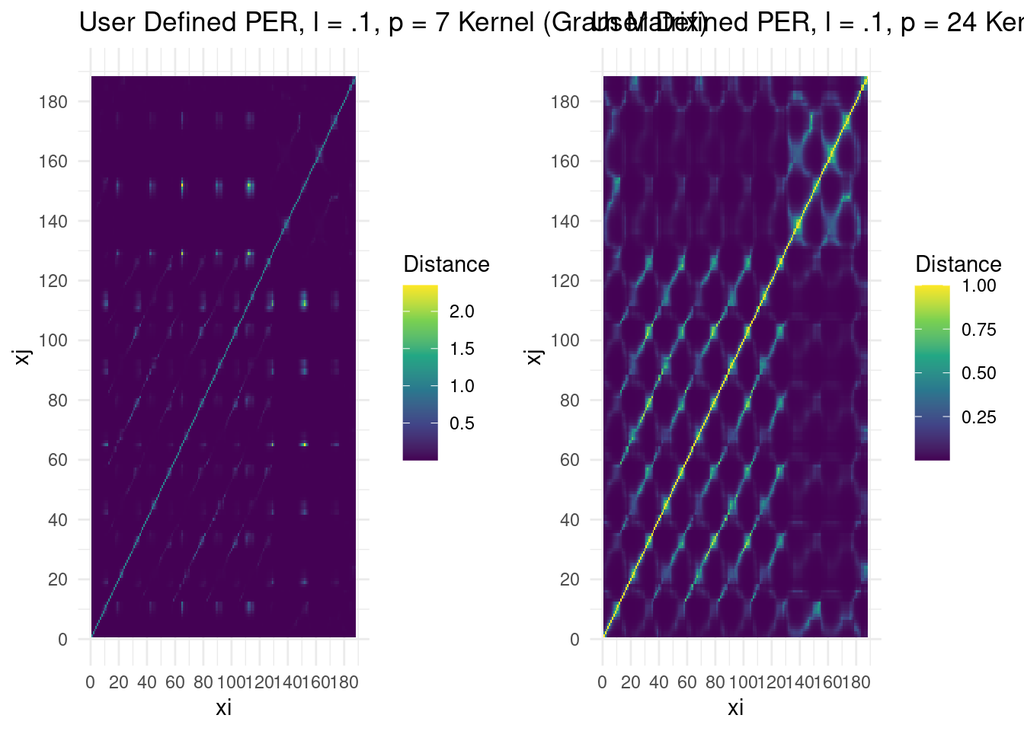

```r
## Generate RBF Kernel and Plot
# PER, l = .1, p = 24
per_gram_1_24 = per_kernel(X_scale_center,.1,24)

# Convert to data frame for plotting
user_kernel_per_1_24_df = per_gram_1_24 %>%
  as.data.frame() %>%
  dplyr::mutate(xi = row_number()) %>%
  pivot_longer(starts_with("V"),names_to = "xj",values_to="Distance") %>%
  as.data.frame() %>%
  mutate(xj = as.numeric(str_remove(xj,"V")))

# Plot
user_kernel_per_1_24_plot = ggplot(data = user_kernel_per_1_24_df, aes(x=xi, y=xj, fill=Distance)) +
  geom_raster() +
  scale_fill_viridis_c() +
  scale_x_continuous(n.breaks = 10) +
  scale_y_continuous(n.breaks = 10) +
  labs(title = "User Defined PER, l = .1, p = 24 Kernel (Gram Matrix)") +
  theme_minimal()


# PER, l = .1, p = 7
per_gram_1_7 = per_kernel(X_scale_center,.1,7)

# Convert to data frame for plotting
user_kernel_per_1_7_df = per_gram_1_7 %>%
  as.data.frame() %>%
  dplyr::mutate(xi = row_number()) %>%
  pivot_longer(starts_with("V"),names_to = "xj",values_to="Distance") %>%
  as.data.frame() %>%
  mutate(xj = as.numeric(str_remove(xj,"V")))

# Plot
user_kernel_per_1_7_plot = ggplot(data = user_kernel_per_1_7_df, aes(x=xi, y=xj, fill=Distance)) +
  geom_raster() +
  scale_fill_viridis_c() +
  scale_x_continuous(n.breaks = 10) +
  scale_y_continuous(n.breaks = 10) +
  labs(title = "User Defined PER, l = .1, p = 7 Kernel (Gram Matrix)") +
  theme_minimal()

# Export image for the report
# uncomment code to export the image
#png(filename = "Images/user_gram_per_01_7vs24.png", width = 1200, height = 480)
plot_grid(user_kernel_per_1_7_plot,user_kernel_per_1_24_plot, labels = NULL, label_size = 12, ncol = 2, nrow = 1)
```

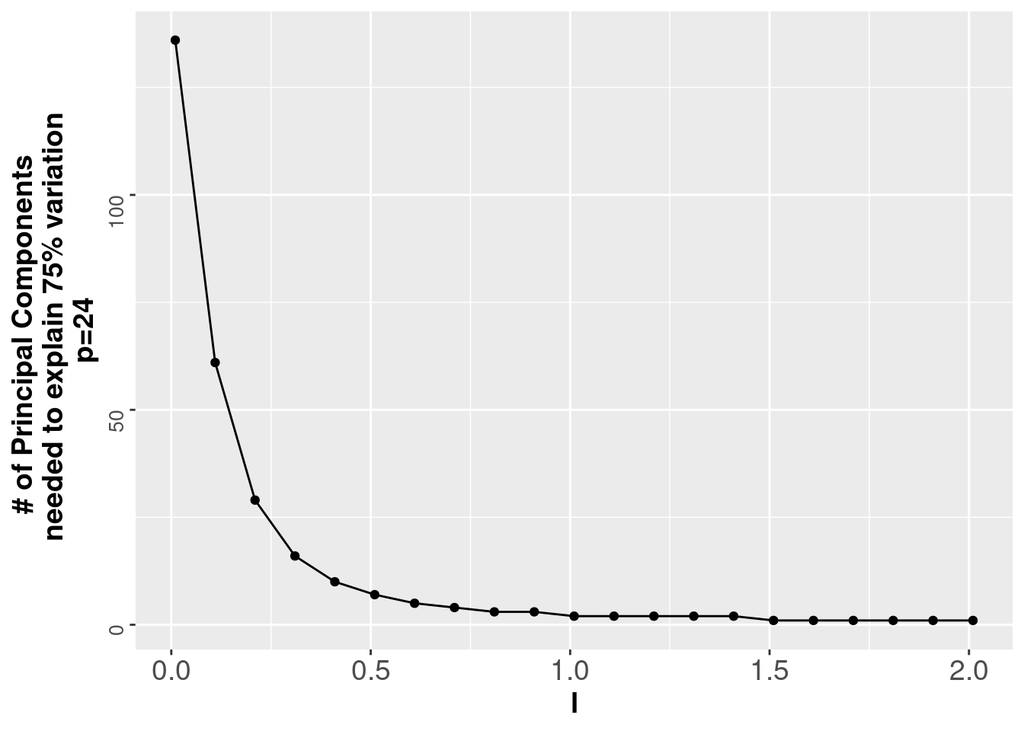

```r
#dev.off()




## Measure relationship between l and number of PCs
# required to get to 75% of variance explained
# fix p = 24

# Define a list of sigmas to explore (l in project formula)
l_list = seq(.01,2.1,by = .1)
p = 24

# Specify dataframe to add the number of PCs (technically loading vectors)
# necessary
per_df = data.frame(l = l_list, pc_count = rep(NA,length(l_list)))

# Counter for loop
counter = 0

# Loop over each value
for (i in l_list) {
  counter = counter + 1

    # Calculate the Gram Matrix
    per_gram = per_kernel(X_scale_center,i,p)

    # Calculate the cumulative variance, as provided
    # by the normalized eigenvalues
    cumeig = cumsum(eigen(per_gram)$values/sum(eigen(per_gram)$values))

    # Get the number of eigenvalues (i.e. PCs) necessary
    # to get to 75%
    number = length(cumeig[which(cumeig < .75)]) + 1

    #store the variable
    per_df[counter,2] = as.numeric(number)

    remove(per_gram,cumeig,number)
}

# Plot the Value of sigma by the variable
pca_count_plot_per = ggplot(data = per_df, aes(x = l, y = pc_count)) +
  geom_point() +
  geom_line() +
  labs(x = "l", y = "# of Principal Components \n needed to explain 75% variation\np=24") +
  theme(text = element_text(size = 20),
    legend.title = element_text(size = 14),
    legend.text = element_text(size = 14),
    legend.key.width=unit(1,"cm"),
    axis.text.y = element_text(angle=90, hjust=1, size = 10),
    axis.text.x = element_text(size = 14),
    axis.title=element_text(size=14,face="bold"))


# Save the output
# Unccoment to output plots
#png(filename = "Images/per_varying_l_p_24.png", width = 960, height = 480)
pca_count_plot_per
```

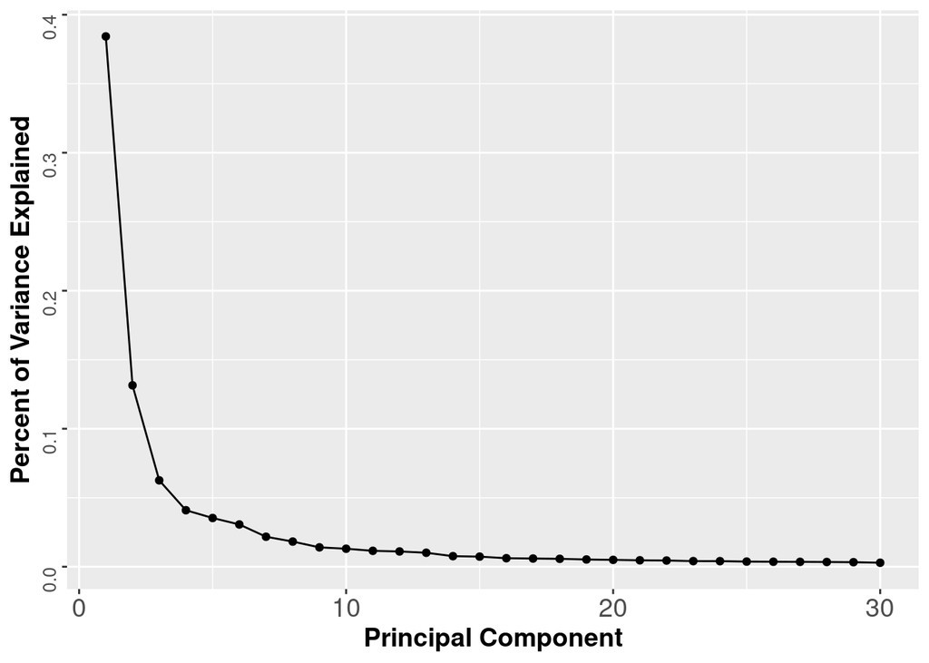

```r
#dev.off




## Scree Plot for l = .4, p = 24
# sigma is defined as the "inverse kernel width on Kernlab", i.e. is in the denominator
kpca_per_4_24 = per_kernel(X_scale_center,.4,24)

per_4_24_eigenvalues = eigen(kpca_per_4_24)$values

# Percent of Variance Explained
percent_variance_explained_per_4_24 =
  data.frame(PC = seq(1,length(per_4_24_eigenvalues),by=1),
             Percent_Variance = (per_4_24_eigenvalues / sum(per_4_24_eigenvalues)))

# Create Scree Plot
# Only show the first 30
kpca_per_scree_4_24 = ggplot(data = percent_variance_explained_per_4_24[1:30,], aes(x = PC, y = Percent_Variance)) +
  geom_point() +
  geom_line() +
  labs(x = "Principal Component", y = "Percent of Variance Explained") +
  theme(text = element_text(size = 20),
    legend.title = element_text(size = 14),
    legend.text = element_text(size = 14),
    legend.key.width=unit(1,"cm"),
    axis.text.y = element_text(angle=90, hjust=1, size = 10),
    axis.text.x = element_text(size = 14),
    axis.title=element_text(size=14,face="bold"))

# plot the output
# uncomment to output plots
#png(filename = "Images/per_4_24.png", width = 480, height = 480)
kpca_per_scree_4_24
```

```r
#dev.off()

# clean environment
remove(kpca_per_4_24,kpca_per_scree_4_24, pca_count_plot_per, per_df,
       per_gram_1_24, per_gram_1_7, percent_variance_explained_per_4_24,
       user_kernel_per_1_24_df, user_kernel_per_1_24_plot, user_kernel_per_1_7_df,
       user_kernel_per_1_7_plot, counter, i, l_list, p, per_4_24_eigenvalues)
```

### Kernel Principal Component Regression

```r
# Perform SVD Using R Function
# To get the Principal components
kpca_per_4_24 = per_kernel(X_scale_center,.4,24)
K_per_svd = svd(kpca_per_4_24)

# Get Principal Compents by m
k_per_pca = K_per_svd$u%*%diag(K_per_svd$d)

# Fit model
kpcr_per = lm(Y_Matrix ~ k_per_pca[,c(1:6)] - 1)
summary(kpcr_per)
```

```
##
## Call:
## lm(formula = Y_Matrix ~ k_per_pca[, c(1:6)] - 1)
##
## Residuals:
##        Min         1Q     Median         3Q        Max
## -0.0270148 -0.0047099 -0.0005655  0.0066314  0.0268217
##
## Coefficients:
##                        Estimate Std. Error t value Pr(>|t|)
## k_per_pca[, c(1:6)]1 -0.0054202  0.0001303 -41.608  < 2e-16 ***
## k_per_pca[, c(1:6)]2 -0.0067609  0.0003808 -17.755  < 2e-16 ***
## k_per_pca[, c(1:6)]3 -0.0031337  0.0007995  -3.919 0.000126 ***
## k_per_pca[, c(1:6)]4  0.0111344  0.0012223   9.109  < 2e-16 ***
## k_per_pca[, c(1:6)]5 -0.0011377  0.0014171  -0.803 0.423120
## k_per_pca[, c(1:6)]6  0.0119072  0.0016338   7.288 9.26e-12 ***
## ---
## Signif. codes:  0 '***' 0.001 '**' 0.01 '*' 0.05 '.' 0.1 ' ' 1
##
## Residual standard error: 0.009411 on 182 degrees of freedom
## Multiple R-squared:  0.9235, Adjusted R-squared:  0.921
## F-statistic: 366.4 on 6 and 182 DF,  p-value: < 2.2e-16
```

```r
# Clean environment
remove(k_per_pca, K_per_svd, kpca_per_4_24)
```